# Trees and Random Forest Example

Jimmy G. Moore

April 9, 2018

## Use the training data set to build a regression tree with ozone (03) as the outcome

To start we will upload the training dataset to our environment. The training data is found at https://bit.ly/2JaHsJn.

```r
#Import Training Set
trainingSet = read.csv("C:/Users/James Moore/Documents/Random_Forrest/dataFile/smogData_train.csv")
trainingSet$X = NULL
```

```r
#format data into training and test set
train = trainingSet[-seq(from = 5,to=255,by=5),]
test = trainingSet[seq(from = 5, to= 255,by = 5),]
```

Now that we have our data formatted properly we will begin building our tree model to predict ozone for our data. Let’s start by just building a tree with all variables as possible predictors. This will give us a good starting point to prune our model.

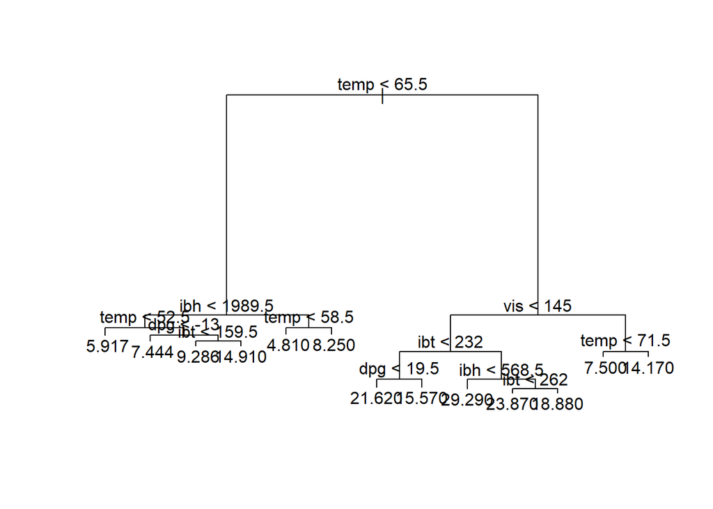

```r
library("tree")
full_tree = tree(O3~.,data = train)
plot(full_tree)
text(full_tree)
```

```r
summary(full_tree)
```

```
##
## Regression tree:
## tree(formula = O3 ~ ., data = train)
## Variables actually used in tree construction:
## [1] "temp" "ibh"  "dpg"  "ibt"  "vis"
## Number of terminal nodes:  13
## Residual mean deviance:  11.26 = 2151 / 191
## Distribution of residuals:
##    Min. 1st Qu.  Median    Mean 3rd Qu.    Max.
## -11.290  -1.810  -0.250   0.000   2.133  11.120
```

Now we will see how the predictions work on our test set by performing cross validation and using the MSE to evaluate performance.

```r
#Make function to calculate MSE
MSE = function(estPred,test){
  squaredError = rep(NA,length(estPred))
  for (i in 1:length(estPred)) {
    squaredError[i] = (estPred[i]-test[i,1])^2
  }
  return(mean(squaredError))
}

#Evaluate Performance
performanceResult = predict(full_tree,test)
MSE(performanceResult,test)
```

```
## [1] 20.7104
```

Our initial MSE is 20.71 which is OK but we would like to prune and control our tree to see if we can reduce this number and/or make the tree a little more simple for interpretation and generalization purposes. To start, we will also modify `nobs`,`mincut`,`minsize`, and `mindev` from `tree.control` to control our tree.

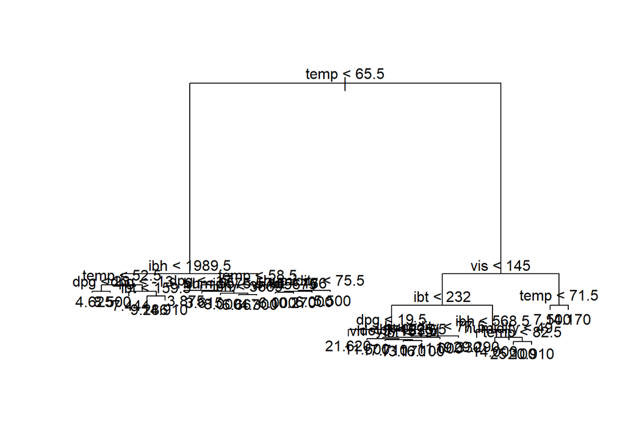

```r
tree_control = tree(O3~.,data = train, control = tree.control(nobs = 204,mincut = 2,minsize = 12,mindev = 0.001))

plot(tree_control)
text(tree_control)
```

```r
summary(tree_control)
```

```
##
## Regression tree:
## tree(formula = O3 ~ ., data = train, control = tree.control(nobs = 204,
##     mincut = 2, minsize = 12, mindev = 0.001))
## Variables actually used in tree construction:
## [1] "temp"     "ibh"      "dpg"      "ibt"      "vh"       "humidity"
## [7] "vis"      "doy"
## Number of terminal nodes:  27
## Residual mean deviance:  8.769 = 1552 / 177
## Distribution of residuals:
##    Min. 1st Qu.  Median    Mean 3rd Qu.    Max.
## -11.290  -1.300  -0.050   0.000   1.308   9.091
```

```r
#Evaluate Performance
performanceResult = predict(tree_control,test)
MSE(performanceResult,test)
```

```
## [1] 18.54274
```

## Abandon CART, focus on Random Forest

We will now shift focus from a single CART Model to a random forest. Ensemble methods are generally better at producing a smaller prediciton variance and for that reason we would like to build one to predict `O3` for or data.

```r
set.seed(1234)
library(randomForest)

#Default Random Forest
forest = randomForest(O3~.,data = train, ntree = 1000, importance = TRUE)

#Evaluate Performance
performanceResult = predict(forest,test)
MSE(performanceResult,test)
```

```
## [1] 8.708602
```

This is a major improvement from our single tree model. Having said that, the previous random forest was a very basic model using many default values. Now we will make some adjustments to see if we can improve our predictions.

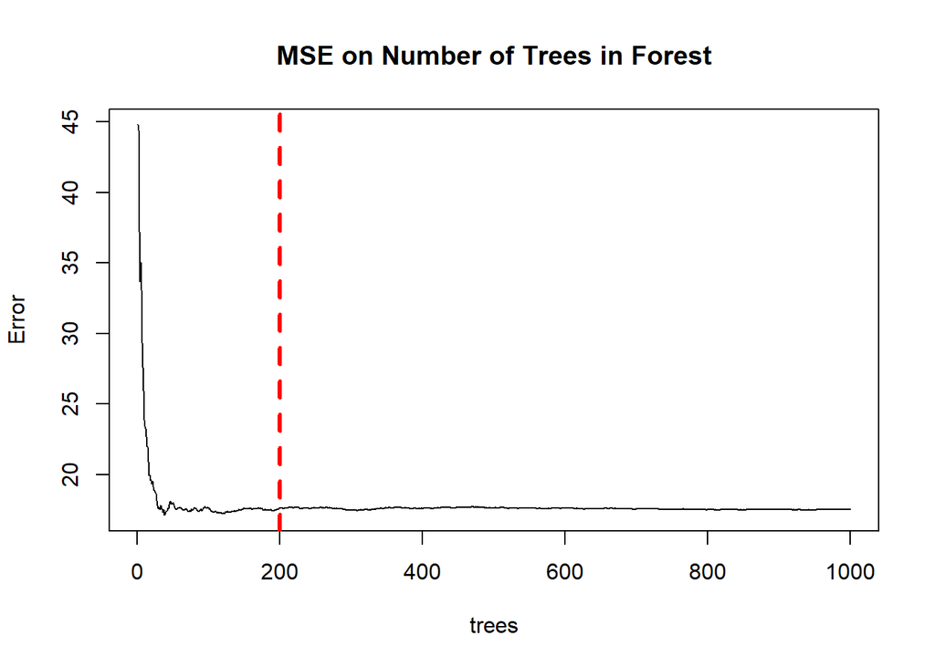

```r
plot(forest,main = "MSE on Number of Trees in Forest")
abline(v = 200, col="red", lwd=3, lty=2)
```

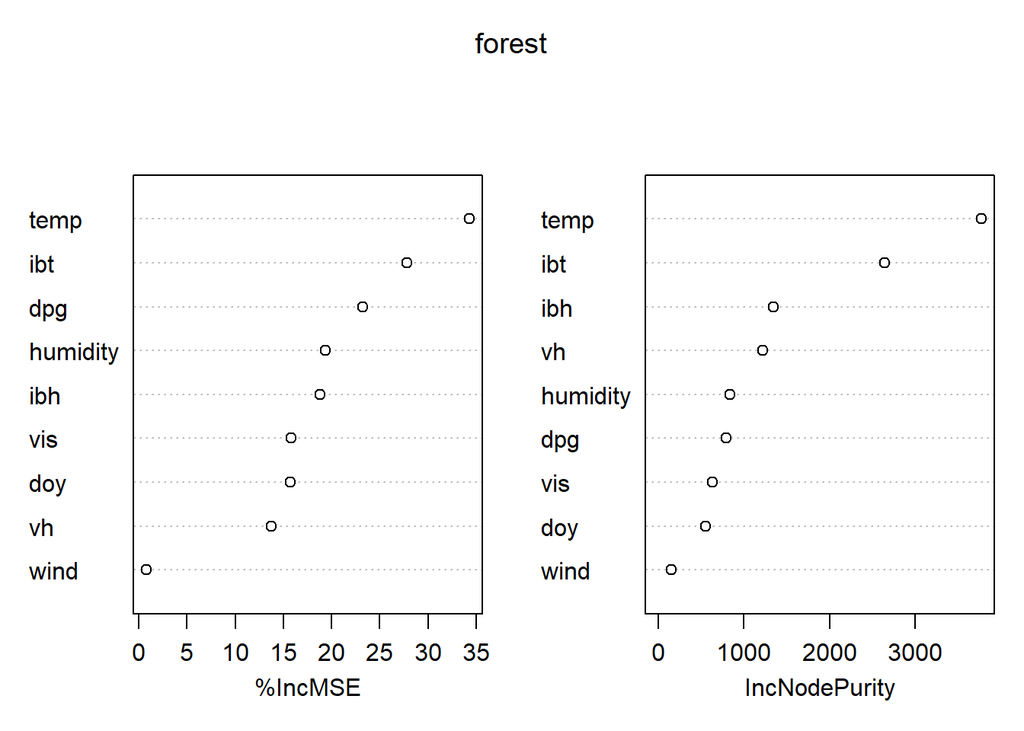

```r
varImpPlot(forest)
```

We can see that the error stabilizes around 200 trees in the model. For that reason we will include that in our final model.

```r
set.seed(1234)

#improved random forest
improve_rf = randomForest(O3~.,data = train, ntree = 200, importance=TRUE,
                          mtry=2,
                          nodesize=3,
                          maxnodes = 100,
                          nPerm = 3,
                          corr.bias = TRUE)

#Evaluate Performance
performanceResult = predict(improve_rf,test)
MSE(performanceResult,test)
```

```
## [1] 8.03463
```

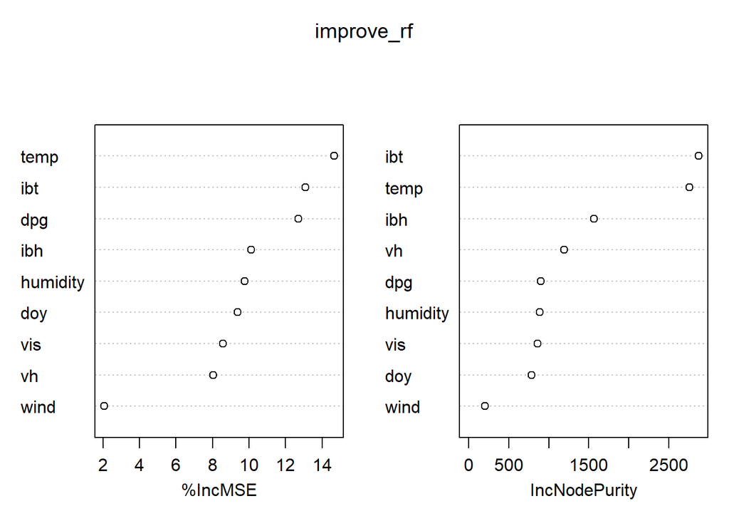

```r
varImpPlot(improve_rf)
```

## Now we will apply our random forest to the prediction data and see how we did.

Start by importing the prediction data

```r
#Import prediciton data
#Import Training Set
testSet = read.csv("C:/Users/James Moore/Documents/Random_Forrest/dataFile/smogDataPredict.csv")
testSet$X = NULL
```

Now we will run prediction with our final Model on the unknown data to see what we can expect

```r
finalPredictions = predict(improve_rf,testSet)
#write predictions to file
write.table(finalPredictions,
            "C:/Users/James Moore/Documents/Random_Forrest/predictionPoints/predicted_O3_Values.txt",row.names = F)
```

Use these final prediction values to evaluate the accuracy of our model. For ease of use the values have been writen to a txt file and is attached with the homework submission.